```r
getwd()
```

```
## [1] "C:/Users/Andrew/Documents/Udacity/dataAnalysisR/EDA_R_Udacity/lesson3"
```

```r
list.files()
```

```
## [1] "lesson3_student.html" "lesson3_student.rmd"  "pseudo_facebook.tsv"
```

```r
pf <- read.csv('pseudo_facebook.tsv', sep = '\t')
names(pf)
```

```
##  [1] "userid"                "age"
##  [3] "dob_day"               "dob_year"
##  [5] "dob_month"             "gender"
##  [7] "tenure"                "friend_count"
##  [9] "friendships_initiated" "likes"
## [11] "likes_received"        "mobile_likes"
## [13] "mobile_likes_received" "www_likes"
## [15] "www_likes_received"
```

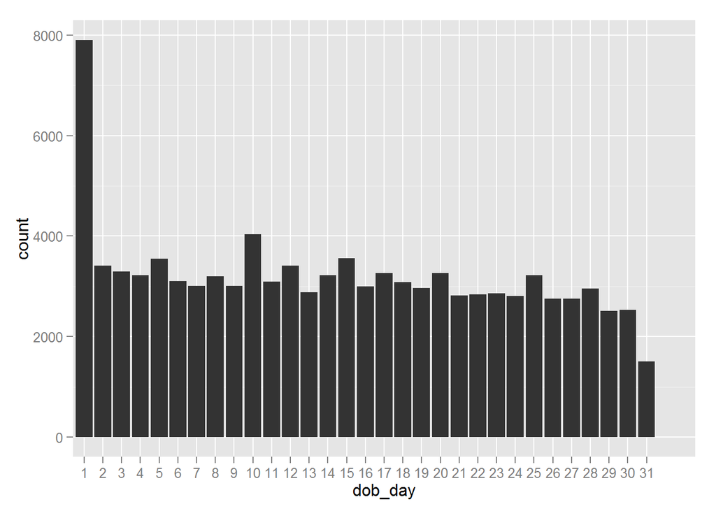

```r
library('ggplot2')
qplot(x = dob_day, data = pf) +
  scale_x_discrete(breaks = 1:31)
```

```r
#install.packages('ggthemes', dependencies = TRUE)
library(ggthemes)
```

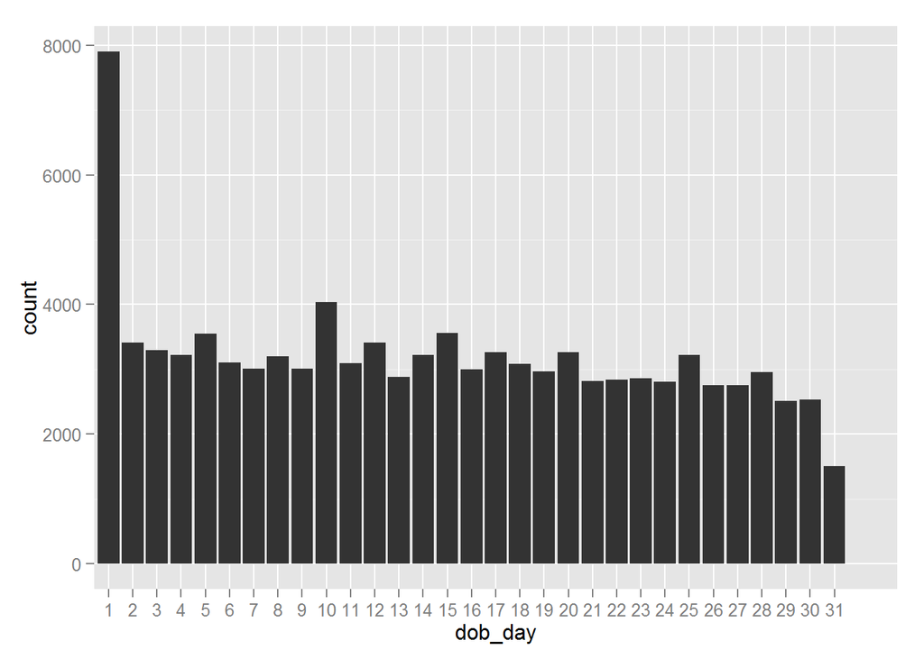

```r
ggplot(aes(x = dob_day), data = pf) +
  geom_histogram() +
  scale_x_discrete(breaks = 1:31)
```

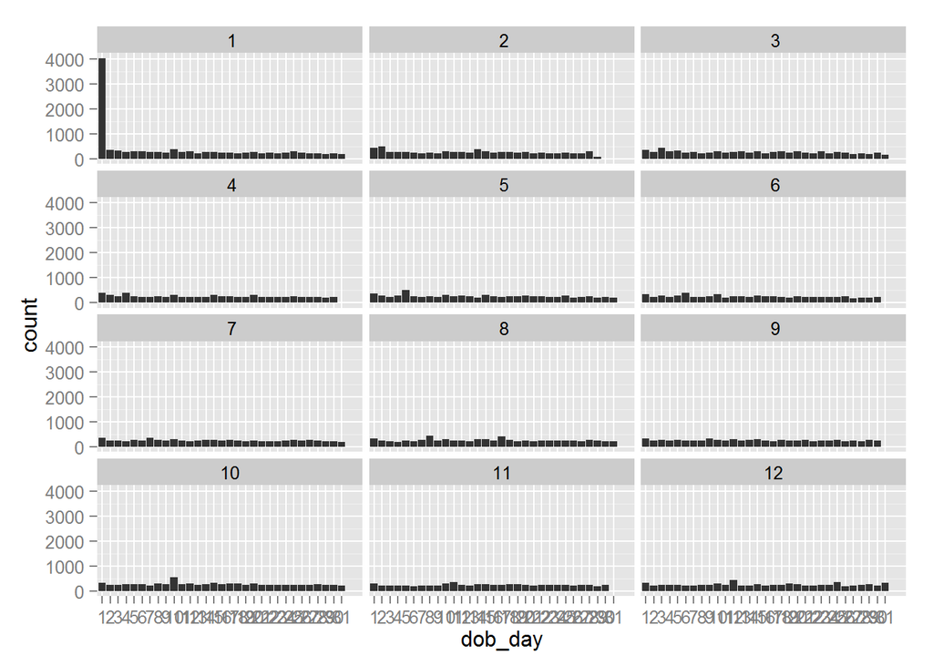

```r
ggplot(aes(x = dob_day), data = pf) +
  geom_histogram() +
  scale_x_discrete(breaks = 1:31) +
  facet_wrap(~dob_month,ncol = 3)
```

```r
summary(pf)
```

```
##      userid             age            dob_day         dob_year
##  Min.   :1000008   Min.   : 13.00   Min.   : 1.00   Min.   :1900
##  1st Qu.:1298806   1st Qu.: 20.00   1st Qu.: 7.00   1st Qu.:1963
##  Median :1596148   Median : 28.00   Median :14.00   Median :1985
##  Mean   :1597045   Mean   : 37.28   Mean   :14.53   Mean   :1976
##  3rd Qu.:1895744   3rd Qu.: 50.00   3rd Qu.:22.00   3rd Qu.:1993
##  Max.   :2193542   Max.   :113.00   Max.   :31.00   Max.   :2000
##
##    dob_month         gender          tenure        friend_count
##  Min.   : 1.000   female:40254   Min.   :   0.0   Min.   :   0.0
##  1st Qu.: 3.000   male  :58574   1st Qu.: 226.0   1st Qu.:  31.0
##  Median : 6.000   NA's  :  175   Median : 412.0   Median :  82.0
##  Mean   : 6.283                  Mean   : 537.9   Mean   : 196.4
##  3rd Qu.: 9.000                  3rd Qu.: 675.0   3rd Qu.: 206.0
##  Max.   :12.000                  Max.   :3139.0   Max.   :4923.0
##                                  NA's   :2
##  friendships_initiated     likes         likes_received
##  Min.   :   0.0        Min.   :    0.0   Min.   :     0.0
##  1st Qu.:  17.0        1st Qu.:    1.0   1st Qu.:     1.0
##  Median :  46.0        Median :   11.0   Median :     8.0
##  Mean   : 107.5        Mean   :  156.1   Mean   :   142.7
##  3rd Qu.: 117.0        3rd Qu.:   81.0   3rd Qu.:    59.0
##  Max.   :4144.0        Max.   :25111.0   Max.   :261197.0
##
##   mobile_likes     mobile_likes_received   www_likes
##  Min.   :    0.0   Min.   :     0.00     Min.   :    0.00
##  1st Qu.:    0.0   1st Qu.:     0.00     1st Qu.:    0.00
##  Median :    4.0   Median :     4.00     Median :    0.00
##  Mean   :  106.1   Mean   :    84.12     Mean   :   49.96
##  3rd Qu.:   46.0   3rd Qu.:    33.00     3rd Qu.:    7.00
##  Max.   :25111.0   Max.   :138561.00     Max.   :14865.00
##
##  www_likes_received
##  Min.   :     0.00
##  1st Qu.:     0.00
##  Median :     2.00
##  Mean   :    58.57
##  3rd Qu.:    20.00
##  Max.   :129953.00
##
```

```r
names(pf)
```

```
##  [1] "userid"                "age"
##  [3] "dob_day"               "dob_year"
##  [5] "dob_month"             "gender"
##  [7] "tenure"                "friend_count"
##  [9] "friendships_initiated" "likes"
## [11] "likes_received"        "mobile_likes"
## [13] "mobile_likes_received" "www_likes"
## [15] "www_likes_received"
```

```
## stat_bin: binwidth defaulted to range/30. Use 'binwidth = x' to adjust this.
```

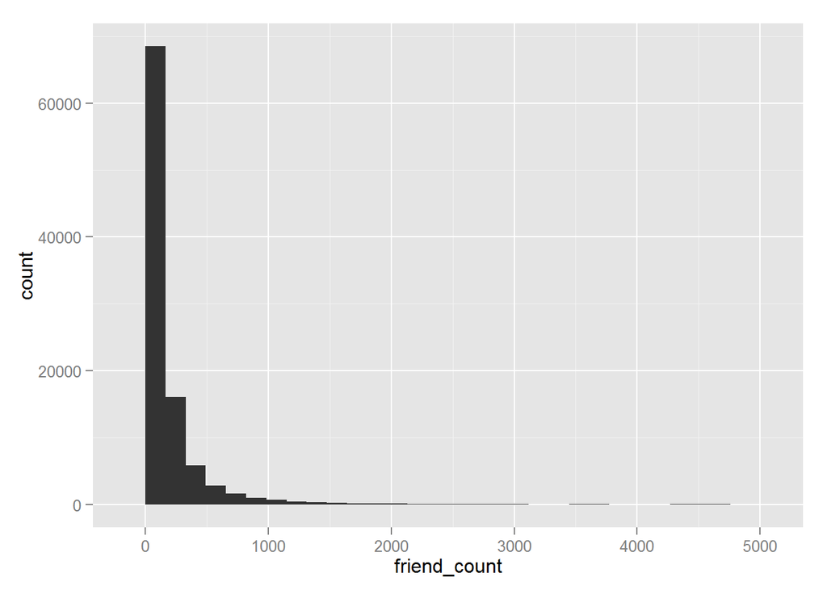

```r
ggplot(aes(x = friend_count), data = pf) +
  geom_histogram()
```

```r
  #+ scale_x_discrete(breaks = 1:31) +
  #facet_wrap(~dob_month,ncol = 3)
```

```
## stat_bin: binwidth defaulted to range/30. Use 'binwidth = x' to adjust this.
```

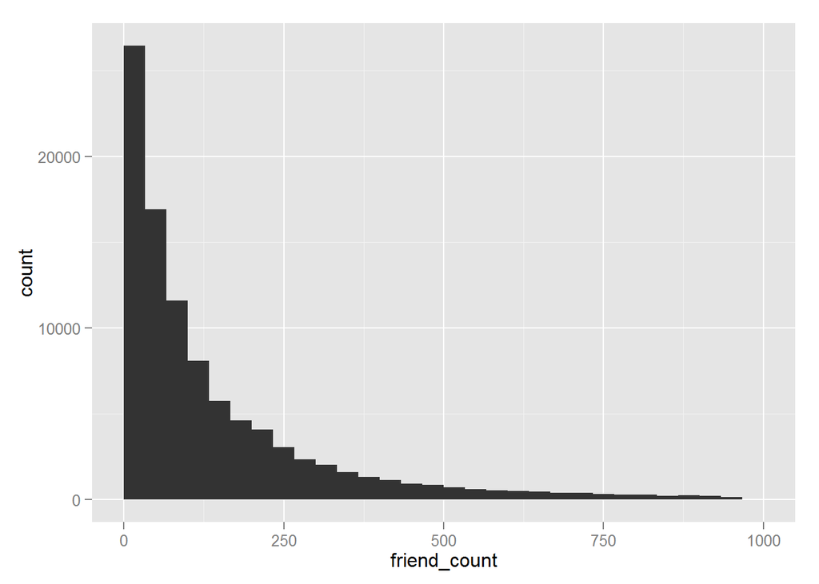

```r
ggplot(aes(x = friend_count), data = pf) +
  geom_histogram() +
  scale_x_continuous(limits = c(0, 1000))
```

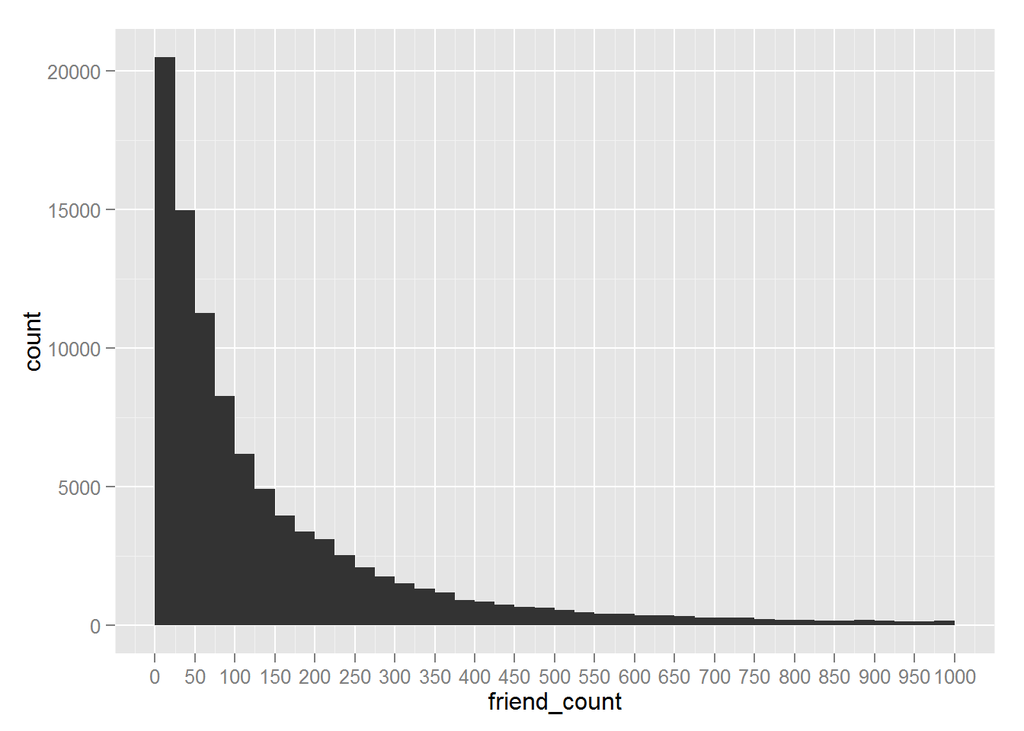

```r
ggplot(aes(x = friend_count), data = pf) +
  geom_histogram(binwidth = 25) +
  scale_x_continuous(limits = c(0, 1000), breaks = seq(0, 1000, 50))
```

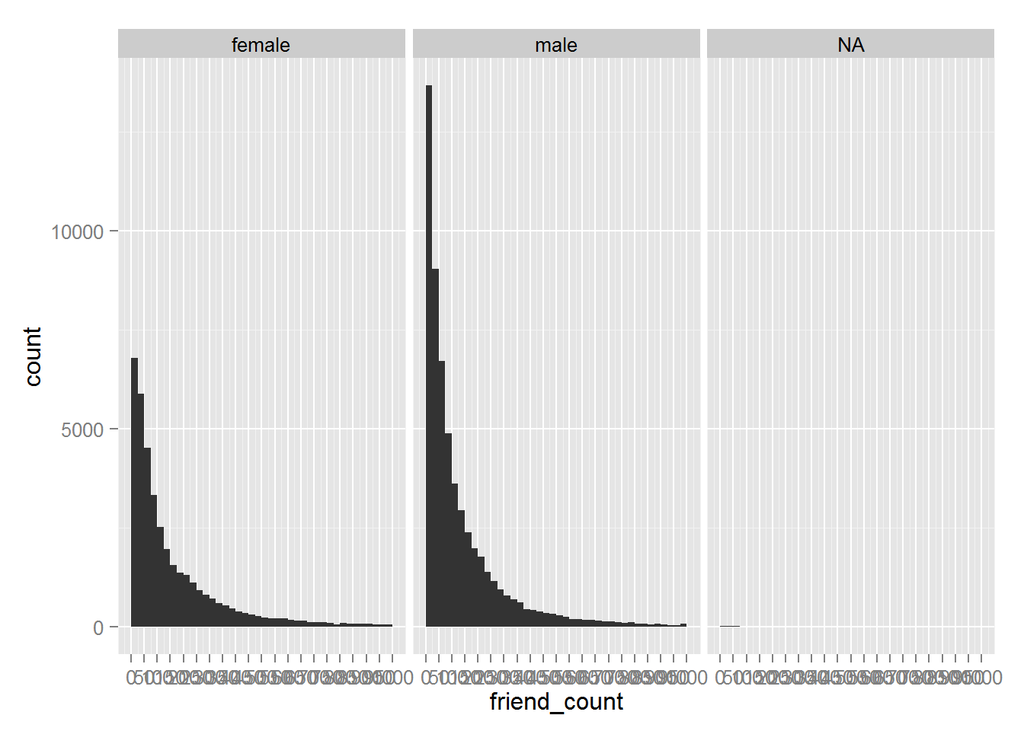

```r
qplot(x = friend_count, data = pf, binwidth = 25) +
  scale_x_continuous(limits = c(0, 1000), breaks = seq(0, 1000, 50)) +
  facet_wrap(~gender)
```

```
## stat_bin: binwidth defaulted to range/30. Use 'binwidth = x' to adjust this.
## stat_bin: binwidth defaulted to range/30. Use 'binwidth = x' to adjust this.
```

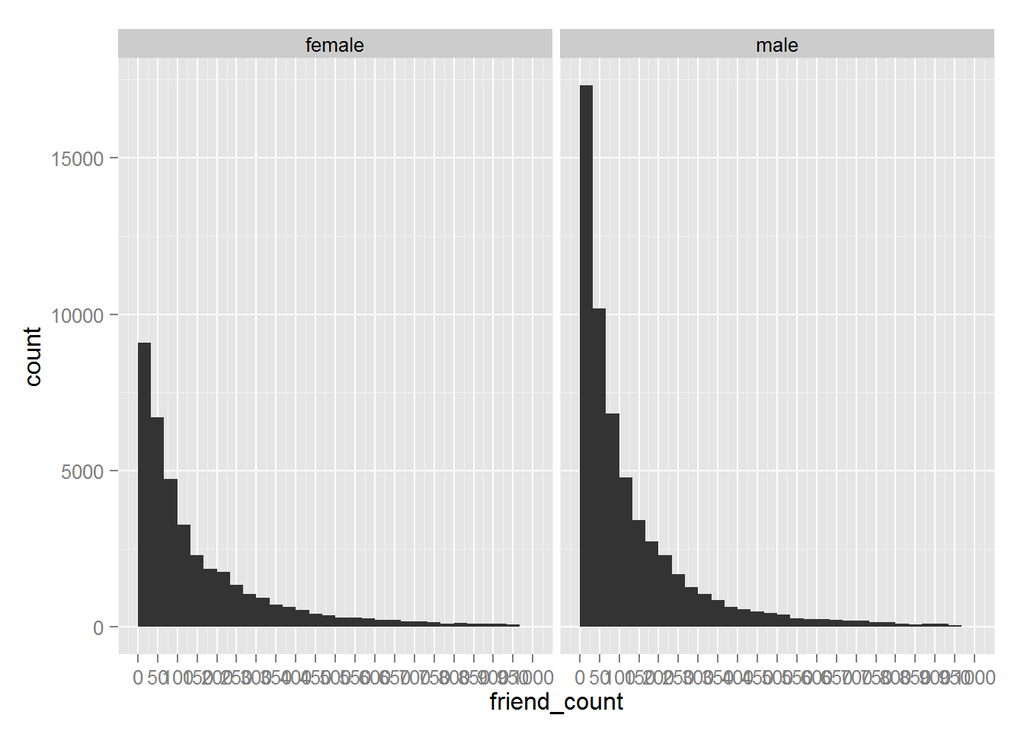

```r
ggplot(aes(x = friend_count), data = subset(pf, !is.na(gender))) +
  geom_histogram() +
  scale_x_continuous(limits = c(0, 1000), breaks = seq(0, 1000, 50)) +
  facet_wrap(~gender)
```

```r
table(pf$gender)
```

```
##
## female   male
##  40254  58574
```

```r
by(pf$friend_count, pf$gender, summary)
```

```
## pf$gender: female
##    Min. 1st Qu.  Median    Mean 3rd Qu.    Max.
##       0      37      96     242     244    4923
## --------------------------------------------------------
## pf$gender: male
##    Min. 1st Qu.  Median    Mean 3rd Qu.    Max.
##       0      27      74     165     182    4917
```

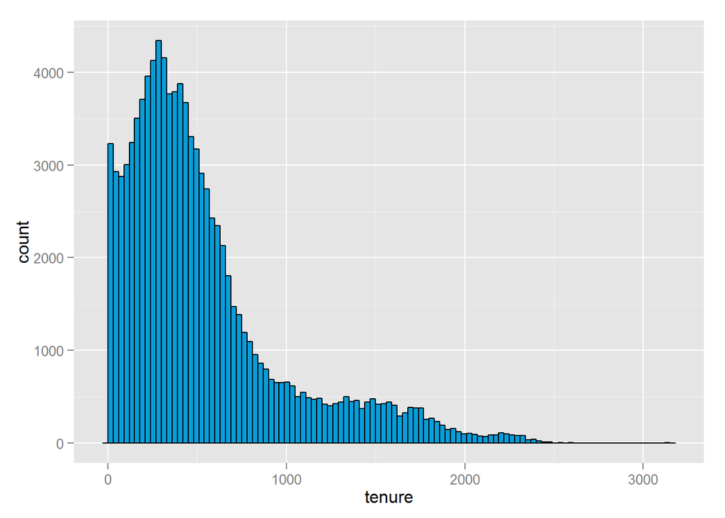

```r
ggplot(aes(x = tenure), data = pf) +
   geom_histogram(binwidth = 30, color = 'black', fill = '#099DD9')
```

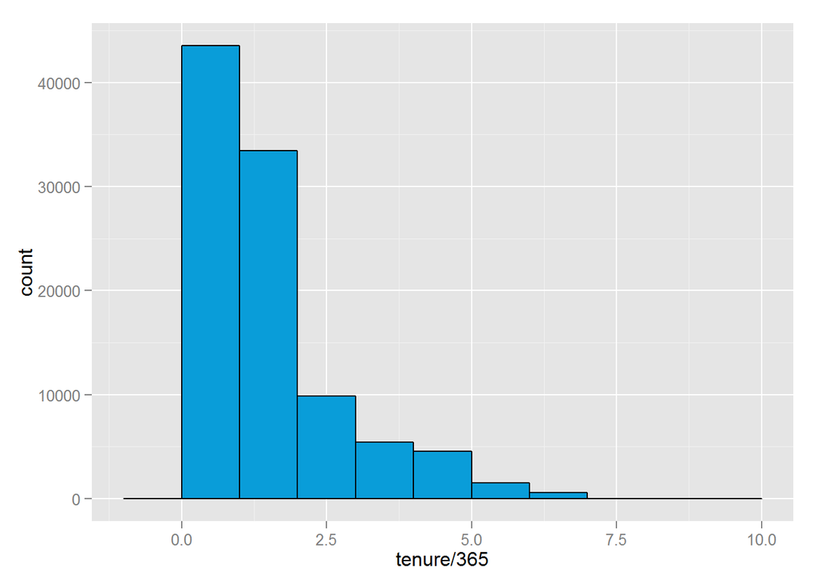

```r
ggplot(aes(x = tenure/365), data = pf) +
   geom_histogram(binwidth = 1, color = 'black', fill = '#099DD9')
```

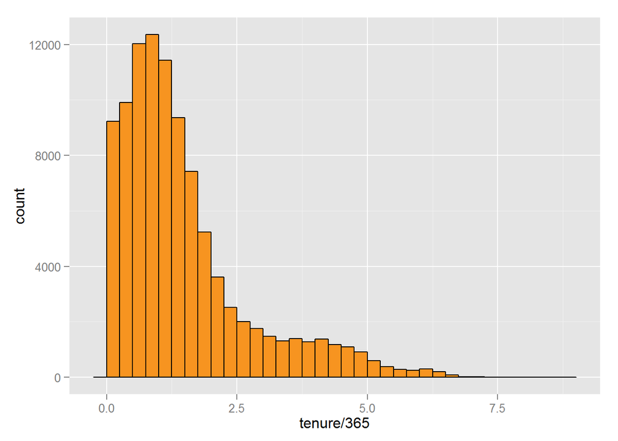

```r
#instructor ggplot solution see notes for qplot solution
ggplot(aes(x = tenure/365), data = pf) +
   geom_histogram(binwidth = .25, color = 'black', fill = '#F79420')
```

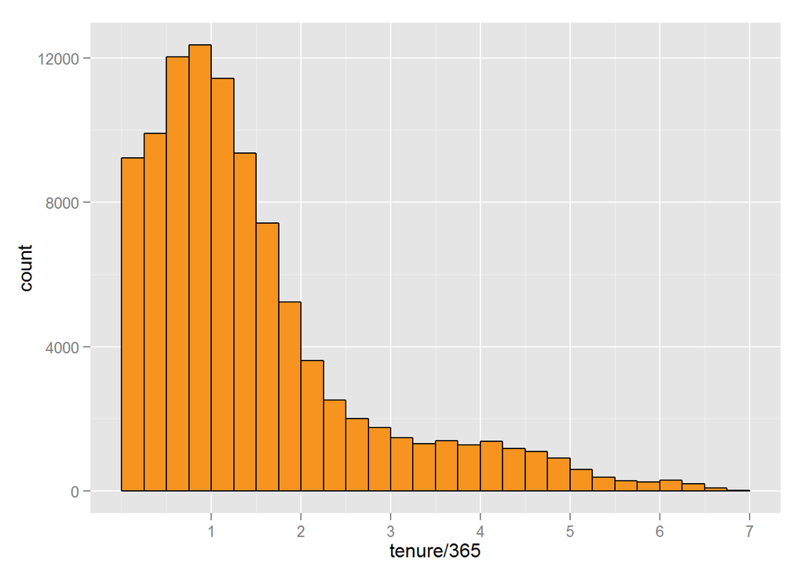

```r
#I set a new scale to zoom in on the data
ggplot(aes(x = tenure/365), data = pf) +
   geom_histogram(binwidth = .25, color = 'black', fill = '#F79420') +
   scale_x_continuous(limits = c(0, 7), breaks = seq(1,7,1))
```

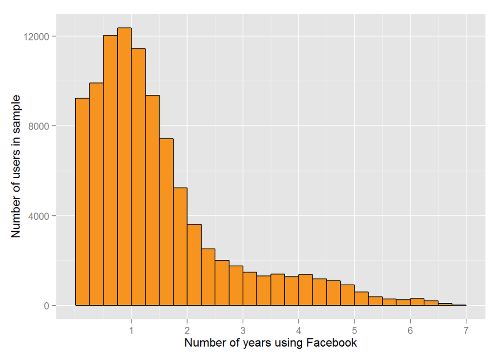

```r
#add labels
ggplot(aes(x = tenure / 365), data = pf) +
  geom_histogram(binwidth = .25,color = 'black', fill = '#F79420') +
  scale_x_continuous(breaks = seq(1, 7, 1), limits = c(0, 7)) +
  xlab('Number of years using Facebook') +
  ylab('Number of users in sample')
```

```r
#quiz to create a histogram of ages and play with data
#what names do we have to work with?
names(pf)
```

```
##  [1] "userid"                "age"
##  [3] "dob_day"               "dob_year"
##  [5] "dob_month"             "gender"
##  [7] "tenure"                "friend_count"
##  [9] "friendships_initiated" "likes"
## [11] "likes_received"        "mobile_likes"
## [13] "mobile_likes_received" "www_likes"
## [15] "www_likes_received"
```

```r
summary(pf$age)
```

```
##    Min. 1st Qu.  Median    Mean 3rd Qu.    Max.
##   13.00   20.00   28.00   37.28   50.00  113.00
```

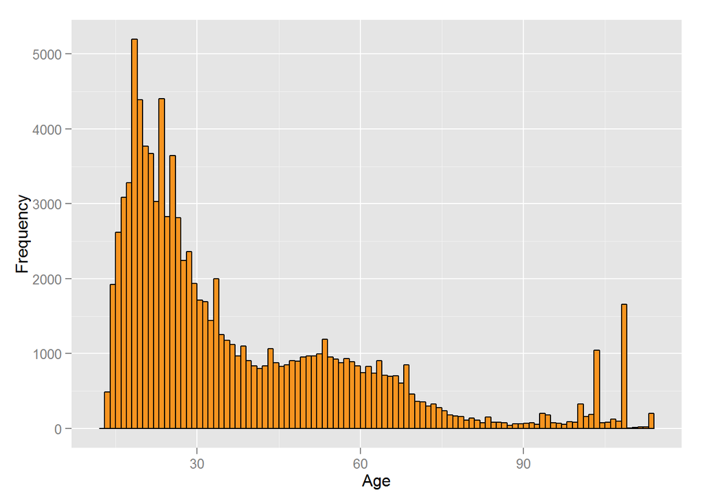

```r
#now to create a histogram of ages
ggplot(aes(x = age), data = pf) +
  geom_histogram(binwidth = 1,color = 'black', fill = '#F79420') +
  xlab('Age') +
  ylab('Frequency')
```

```r
#hmm, the upper extremes strain credulity
```

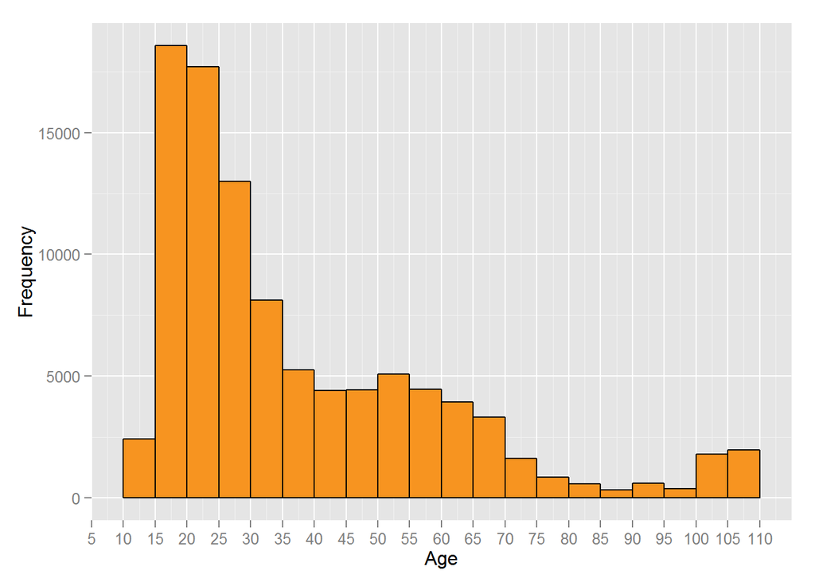

```r
#let's split this up a bit
ggplot(aes(x = age), data = pf) +
  geom_histogram(binwidth = 5,color = 'black', fill = '#F79420') +
  scale_x_continuous(breaks = seq(5, 110, 5), limits = c(10, 110)) +
  xlab('Age') +
  ylab('Frequency')
```

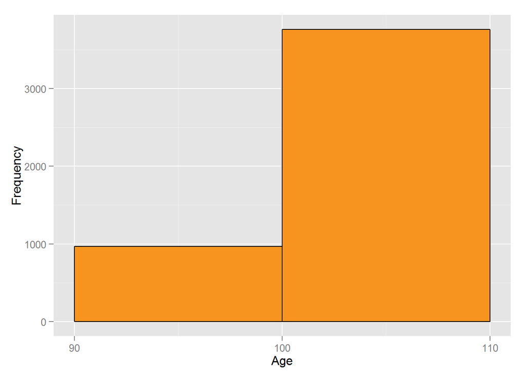

```r
#let's look at that upper range
ggplot(aes(x = age), data = pf) +
  geom_histogram(binwidth = 10,color = 'black', fill = '#F79420') +
  scale_x_continuous(breaks = seq(10, 110, 10), limits = c(90, 110)) +
  xlab('Age') +
  ylab('Frequency')
```

```r
#install.packages('gridExtra')
library(gridExtra)
```

```
## stat_bin: binwidth defaulted to range/30. Use 'binwidth = x' to adjust this.
## stat_bin: binwidth defaulted to range/30. Use 'binwidth = x' to adjust this.
```

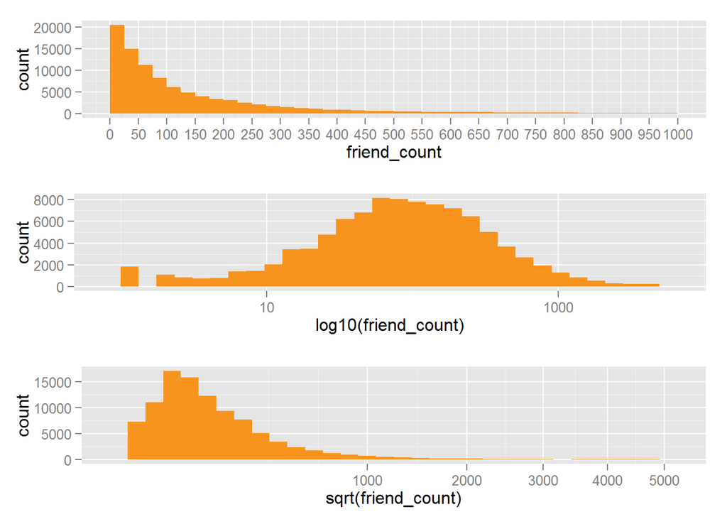

```r
#create 1 column with 3 histograms: friend count, log10 friend count, sqrt friend #count

p1 = ggplot(aes(x = friend_count), data = pf) +
  geom_histogram(binwidth = 25, fill = '#F79420') +
  scale_x_continuous(limits = c(0, 1000), breaks = seq(0, 1000, 50))

p2 = ggplot(aes(x = friend_count), data = pf) +
  geom_histogram(fill = '#F79420') +
  scale_x_log10() +
  xlab('log10(friend_count)')

p3 = ggplot(aes(x = friend_count), data = pf) +
  geom_histogram(fill = '#F79420') +
  scale_x_sqrt() +
  xlab('sqrt(friend_count)')


# arrange plots in grid
grid.arrange(p1, p2, p3, ncol=1)
```

```
## stat_bin: binwidth defaulted to range/30. Use 'binwidth = x' to adjust this.
## stat_bin: binwidth defaulted to range/30. Use 'binwidth = x' to adjust this.
## stat_bin: binwidth defaulted to range/30. Use 'binwidth = x' to adjust this.
```

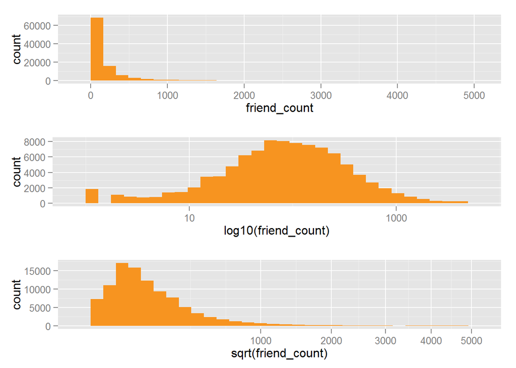

```r
#Here is a better way of doing it
p1 = ggplot(aes(x = friend_count), data = pf) +
  geom_histogram(fill = '#F79420')

p2 = p1 + scale_x_log10() +
  xlab('log10(friend_count)')

p3 = p1 +
  scale_x_sqrt() +
  xlab('sqrt(friend_count)')

grid.arrange(p1,p2,p3,ncol=1)
```

```
## stat_bin: binwidth defaulted to range/30. Use 'binwidth = x' to adjust this.
```

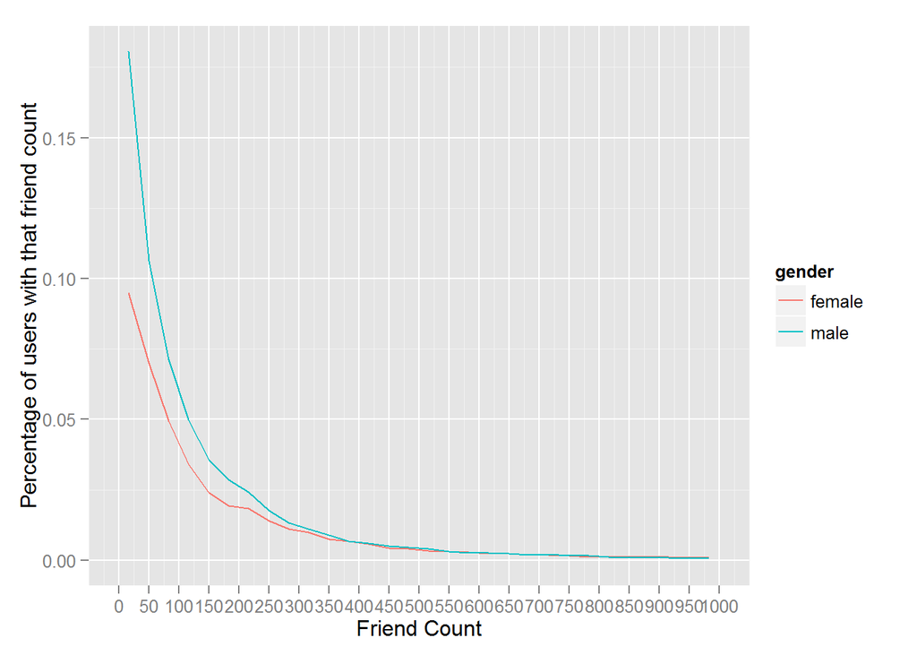

```r
#Use a frequency polygon to determine which gender makes more likes on the www (www_likes)

#we need to subset the data for not gender = na and add y ..etc to get proportion. The latter is because there are many more males than females in the data set.  We know from previous analysis that females tend to have more likes, where does the transitions occur?

ggplot(aes(x = friend_count, y = ..count../sum(..count..)), data = subset(pf, !is.na(gender))) +
  geom_freqpoly(aes(color = gender)) +
  scale_x_continuous(limits = c(0, 1000), breaks = seq(0, 1000, 50)) +
  xlab('Friend Count') +
  ylab('Percentage of users with that friend count')
```

```
## stat_bin: binwidth defaulted to range/30. Use 'binwidth = x' to adjust this.
```

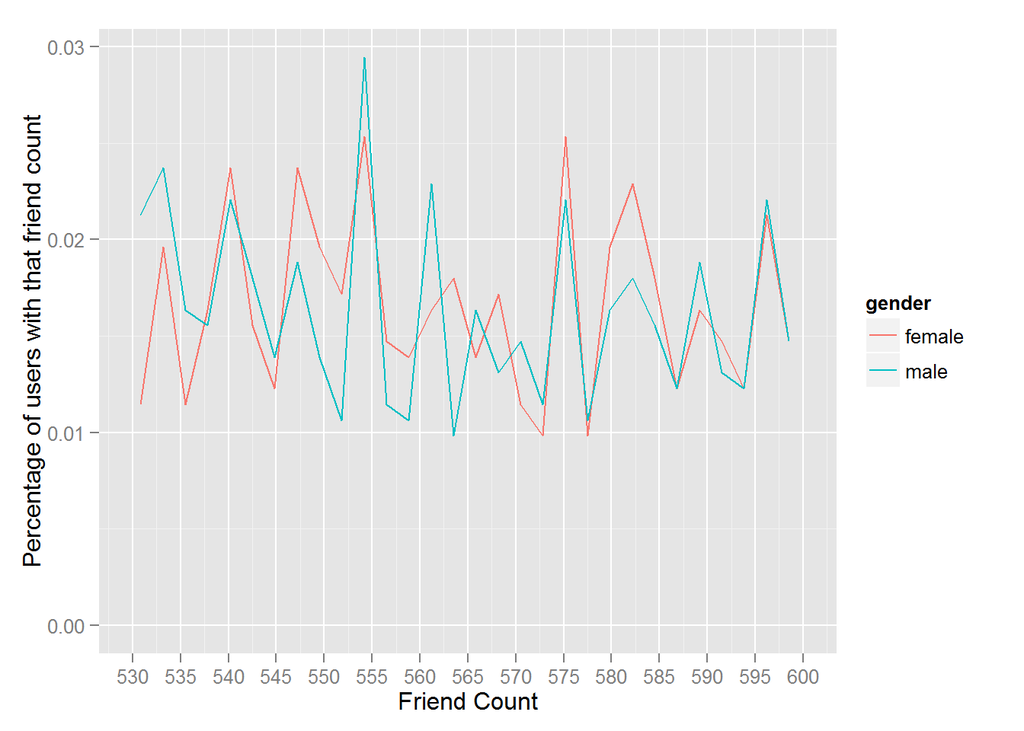

```r
#changing plot range

ggplot(aes(x = friend_count, y = ..count../sum(..count..)), data = subset(pf, !is.na(gender))) +
  geom_freqpoly(aes(color = gender)) +
  scale_x_continuous(limits = c(530, 600), breaks = seq(530, 600, 5)) +
  xlab('Friend Count') +
  ylab('Percentage of users with that friend count')
```

```
## stat_bin: binwidth defaulted to range/30. Use 'binwidth = x' to adjust this.
```

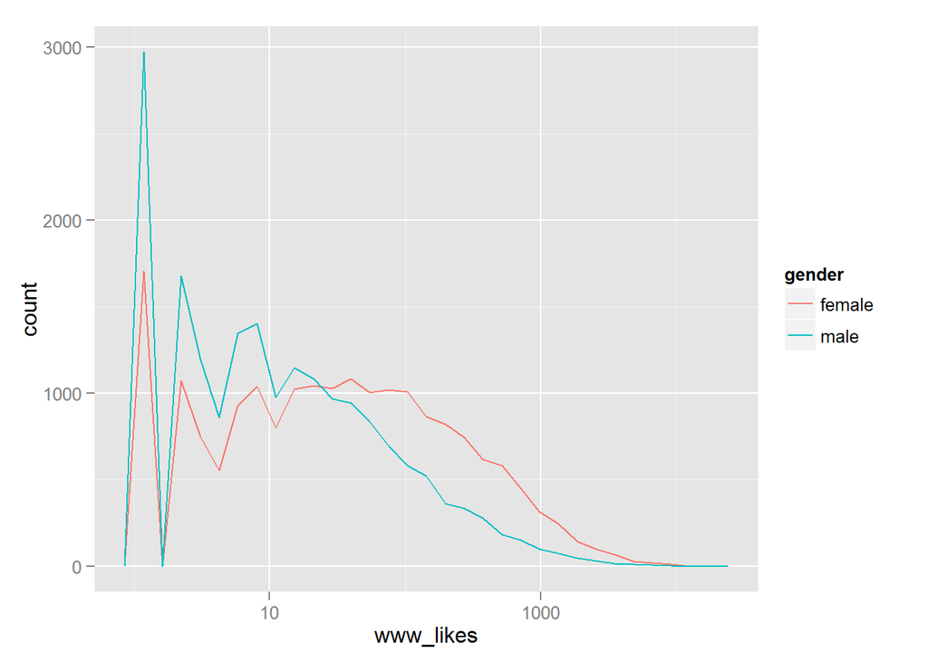

```r
#I need to do some more work:  - www_likes is a count variable and should be plotted on a discrete scale  - www_like is long tail data which may benefit from a log tranformation

ggplot(aes(x = www_likes), data = subset(pf, !is.na(gender))) +
  geom_freqpoly(aes(color = gender)) +
  scale_x_log10()
```

**test markdown outside r block:**

```r
#let's look at this numerically

sum(subset(pf$www_likes, pf$gender == 'male'))
```

```
## [1] 1430175
```

**compare means**

```r
by(pf$www_likes, pf$gender, summary)
```

```
## pf$gender: female
##     Min.  1st Qu.   Median     Mean  3rd Qu.     Max.
##     0.00     0.00     0.00    87.14    25.00 14860.00
## --------------------------------------------------------
## pf$gender: male
##     Min.  1st Qu.   Median     Mean  3rd Qu.     Max.
##     0.00     0.00     0.00    24.42     2.00 12900.00
```

**compare sum**

```r
by(pf$www_likes, pf$gender, sum)
```

```
## pf$gender: female
## [1] 3507665
## --------------------------------------------------------
## pf$gender: male
## [1] 1430175
```

**look at the means, females have more likes**

## Back to Friend Counts

**Adjust code to:** - focus on users in population sample who have friend counts between 0 and 1000. - going to try this with qplot and ggplot

### basic qplot

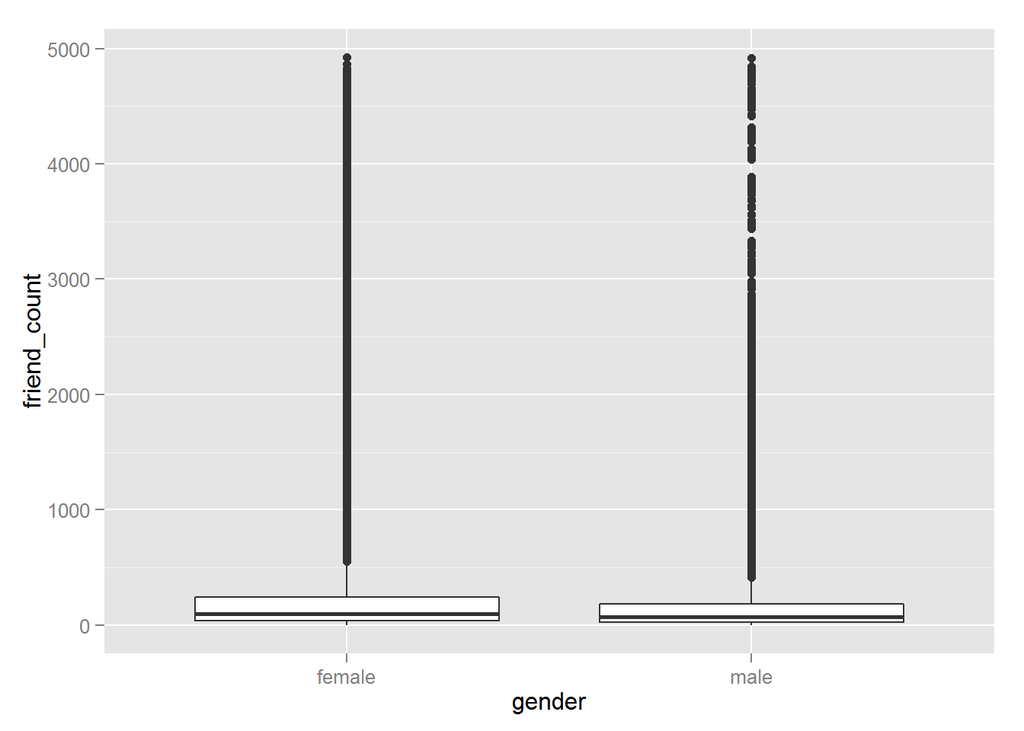

```r
qplot(x = gender, y = friend_count,data = subset(pf,!is.na(gender)),geom = 'boxplot')
```

**let’s try to zoom in closer to the IQR**

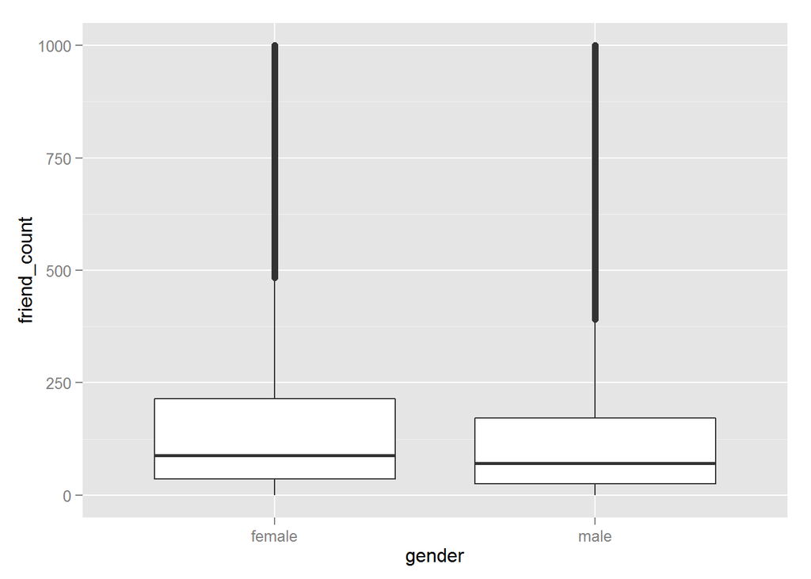

```r
qplot(x = gender, y = friend_count,data = subset(pf,!is.na(gender)),geom = 'boxplot',ylim = c(0,1000))
```

**so it turns out that ylim removes data points, to get around this I will add a scale_y_continuous layer**

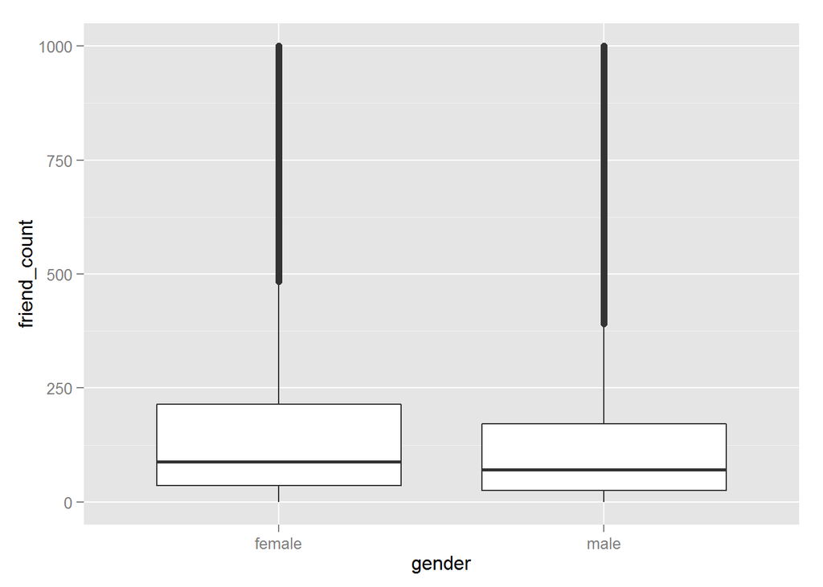

```r
qplot(x = gender, y = friend_count,data = subset(pf,!is.na(gender)),geom = 'boxplot') +
  scale_y_continuous(limits = c(0,1000))
```

**ZOMG! this removes points too, one more time with coord_cartesian()**

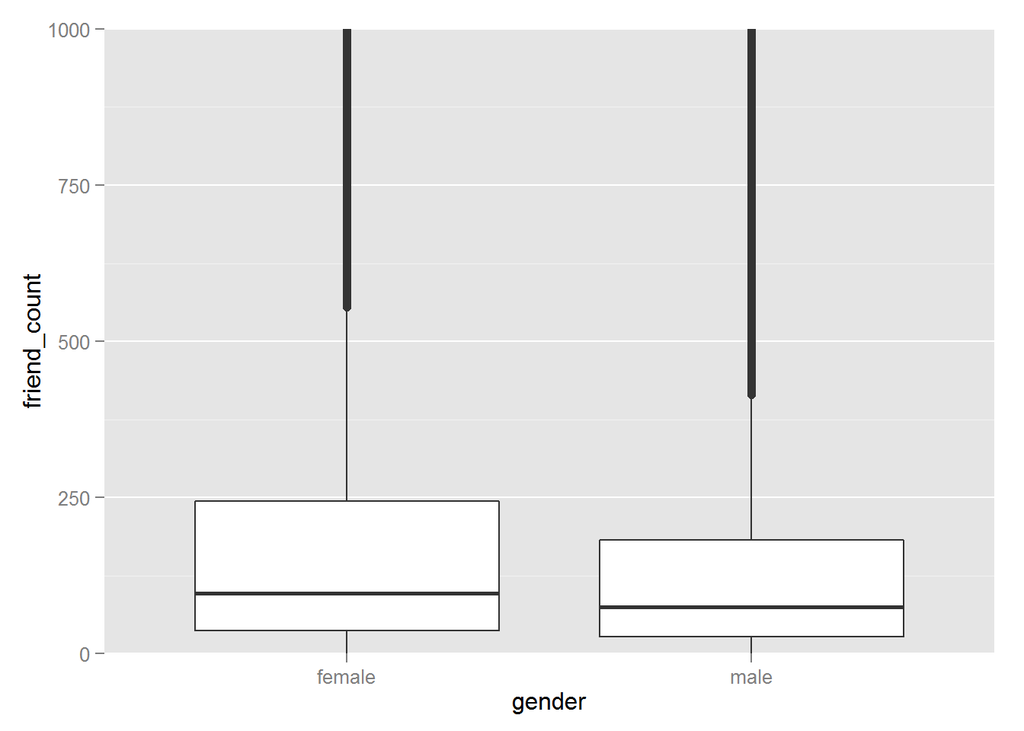

```r
qplot(x = gender, y = friend_count,data = subset(pf,!is.na(gender)),geom = 'boxplot') +
  coord_cartesian(ylim = c(0,1000))
```

**ok good, that did not remove data, now to replicate in ggplot** **update decided to move on to other things and circle back**

**median (black line) slightly higher for females, let’s look more closely**

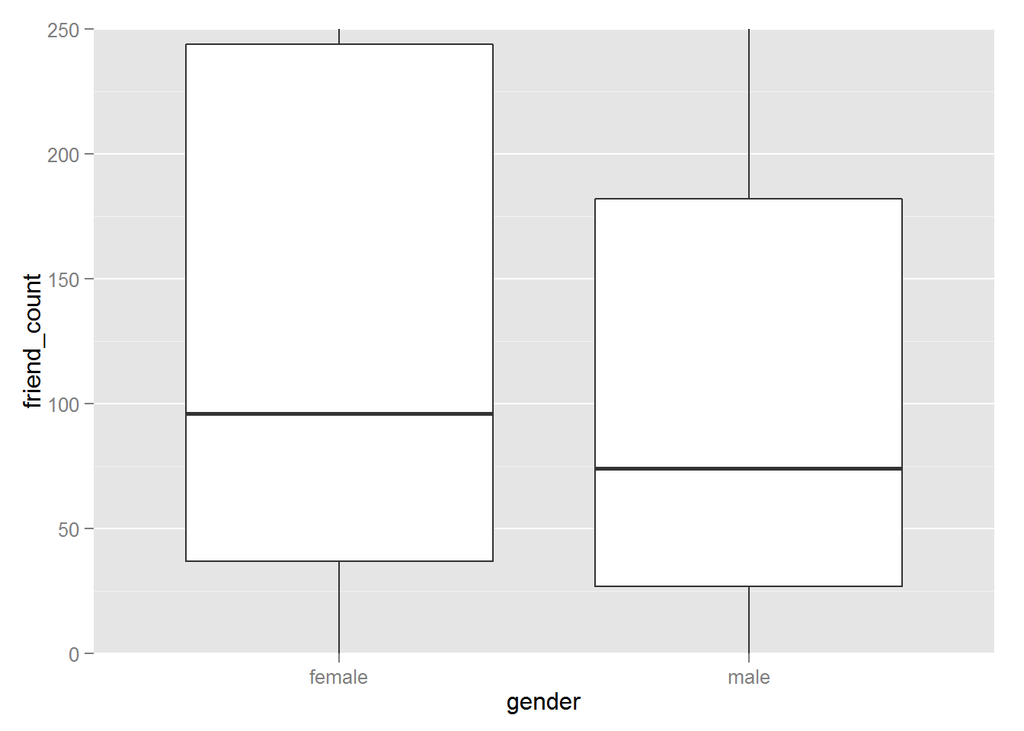

```r
qplot(x = gender, y = friend_count,data = subset(pf,!is.na(gender)),geom = 'boxplot') +
  coord_cartesian(ylim = c(0,250))
```

**yeah, slightly higher**

### Does this match our tables?

```r
by(pf$friend_count,pf$gender,summary)
```

```
## pf$gender: female
##    Min. 1st Qu.  Median    Mean 3rd Qu.    Max.
##       0      37      96     242     244    4923
## --------------------------------------------------------
## pf$gender: male
##    Min. 1st Qu.  Median    Mean 3rd Qu.    Max.
##       0      27      74     165     182    4917
```

**So we know this now, but what we don’t know is who actually initiated more friendships? Who is more active in trying to obtain friends**

**What do we have to choose from?**

```r
names(pf)
```

```
##  [1] "userid"                "age"
##  [3] "dob_day"               "dob_year"
##  [5] "dob_month"             "gender"
##  [7] "tenure"                "friend_count"
##  [9] "friendships_initiated" "likes"
## [11] "likes_received"        "mobile_likes"
## [13] "mobile_likes_received" "www_likes"
## [15] "www_likes_received"
```

**Looks like friendships initiated is the way to go**

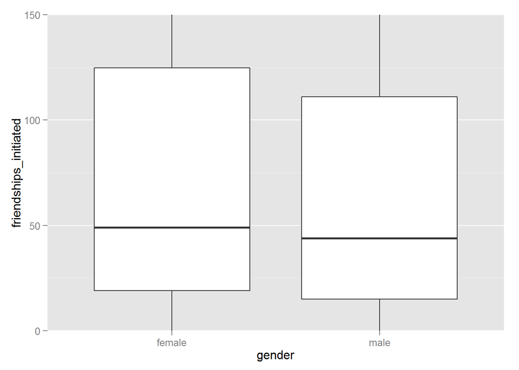

```r
qplot(x = gender, y = friendships_initiated,data = subset(pf,!is.na(gender)),geom = 'boxplot') +
  coord_cartesian(ylim = c(0,150))
```

```r
by(pf$friendships_initiated,pf$gender,summary)
```

```
## pf$gender: female
##    Min. 1st Qu.  Median    Mean 3rd Qu.    Max.
##     0.0    19.0    49.0   113.9   124.8  3654.0
## --------------------------------------------------------
## pf$gender: male
##    Min. 1st Qu.  Median    Mean 3rd Qu.    Max.
##     0.0    15.0    44.0   103.1   111.0  4144.0
```

**And the females have it ladies and gentlemen!**

## What percent of users check in using mobile (binary analysis)?

```r
summary(pf$mobile_likes)
```

```
##    Min. 1st Qu.  Median    Mean 3rd Qu.    Max.
##     0.0     0.0     4.0   106.1    46.0 25110.0
```

**wow, a lot of zeros**

```r
summary(pf$mobile_likes > 0)
```

```
##    Mode   FALSE    TRUE    NA's
## logical   35056   63947       0
```

**much better**

```r
#assign new column to NA
pf$mobile_check_in <- NA
#use if else statement to alter values base on mobile likes, if they did a mobile like, they use mobile, if not, probably not.  So if mobile likes are gt 0, then assing one, else assign o.  This is just like excel syntax FYI.
pf$mobile_check_in <-ifelse(pf$mobile_likes > 0,1,0)
#set factor levels
pf$mobile_check_in <- factor(pf$mobile_check_in)
#summarize the data
summary(pf$mobile_check_in)
```

```
##     0     1
## 35056 63947
```

#### Now how about that %

```r
#divide the summarry by the length of the vector then multiply by 100
summary(pf$mobile_check_in)/length(pf$mobile_check_in) *100
```

```
##        0        1
## 35.40903 64.59097
```

**I could have answere this more specfically for the True (value = 1) case**

```r
sum(pf$mobile_check_in == 1)/length(pf$mobile_check_in) *100
```

```
## [1] 64.59097
```